# Notebook 11 – Solutions

## Getting Started

Before running this notebook, select “Session > Restart R and Clear Output” in the menu above to start a new R session. This will clear any old data sets and give us a blank slate to start with.

After starting a new session, run the following code chunk to load the libraries and data that we will be working with today.

Today’s notebook will be a bit more open-ended in nature than the previous ones we have worked on. Instead of rushing through the questions by finding an easy answer, try to think of something interesting to do with the data.

## Shakespeare Plays

The data for today comes from the text of Shakespeare’s plays. The main table consists of one row for each spoken line in every play included in the first folio. The `globalnumber` gives the line number within the entire play and the `speech_id` feature gives a way of referencing a set of contiguous lines said by one speaker.

```r
lines <- read_csv("../data/shakespeare_lines.csv.bz2")
lines
```

```
## # A tibble: 112,102 × 9
##    play    act scene act_scene globalnumber number full_name text  speech_id
##    <chr> <dbl> <dbl> <chr>            <dbl>  <dbl> <chr>     <chr>     <dbl>
##  1 All'…     1     1 1.1                  1      1 Countess… In d…         1
##  2 All'…     1     1 1.1                  2      2 Countess… cond…         1
##  3 All'…     1     1 1.1                  3      3 Bertram,… And …         2
##  4 All'…     1     1 1.1                  4      4 Bertram,… fath…         2
##  5 All'…     1     1 1.1                  5      5 Bertram,… stie…         2
##  6 All'…     1     1 1.1                  6      6 Bertram,… in s…         2
##  7 All'…     1     1 1.1                  7      7 Lafew     You …         3
##  8 All'…     1     1 1.1                  8      8 Lafew     you …         3
##  9 All'…     1     1 1.1                  9      9 Lafew     must…         3
## 10 All'…     1     1 1.1                 10     10 Lafew     ness…         3
## # ℹ 112,092 more rows
```

We also have metadata about each of the plays. The dates of the plays are not known precisely. The variables `year_post_quem` and `year_ante_quem` give the earliest and latest years that the play was believed to have been written.

```r
plays <- read_csv("../data/shakespeare_plays.csv")
plays
```

```
## # A tibble: 37 × 5
##    play                     genre year_post_quem year_ante_quem problem_play
##    <chr>                    <chr>          <dbl>          <dbl>        <dbl>
##  1 All's Well That Ends We… come…           1602           1603            1
##  2 Antony and Cleopatra     trag…           1606           1607            0
##  3 As You Like It           come…           1599           1600            0
##  4 Comedie of Errors        come…           1592           1593            0
##  5 Coriolanus               trag…           1607           1608            0
##  6 Cymbeline                trag…           1609           1610            1
##  7 Hamlet                   trag…           1600           1601            0
##  8 Henry IV, Pt. 1          hist…           1597           1598            0
##  9 Henry IV, Pt. 2          hist…           1597           1598            0
## 10 Henry V                  hist…           1598           1599            0
## # ℹ 27 more rows
```

We also have a table about the individual characters in each of the plays:

```r
people <- read_csv("../data/shakespeare_people.csv.bz2")
people
```

```
## # A tibble: 1,615 × 4
##    play                      full_name                    short_name gender
##    <chr>                     <chr>                        <chr>      <chr>
##  1 All's Well That Ends Well King of France               KING.      male
##  2 All's Well That Ends Well Duke of Florence             DUKE.      male
##  3 All's Well That Ends Well Bertram, Count of Roussillon BER.       male
##  4 All's Well That Ends Well Lafew                        LAF.       male
##  5 All's Well That Ends Well Parolles                     PAR.       male
##  6 All's Well That Ends Well Rinaldo                      STEW.      male
##  7 All's Well That Ends Well Lavatch                      CLO.       male
##  8 All's Well That Ends Well Countess's Page              PAGE.      male
##  9 All's Well That Ends Well Gentleman                    GENT.      male
## 10 All's Well That Ends Well Countess of Roussillon       COUNT.     female
## # ℹ 1,605 more rows
```

As well as a collection of stage instructions:

```r
stage <- read_csv("../data/shakespeare_sd.csv.bz2")
stage
```

```
## # A tibble: 4,328 × 6
##    play                        act scene sdglobalnumber sdnumber direction
##    <chr>                     <dbl> <dbl>          <dbl>    <dbl> <chr>
##  1 All's Well That Ends Well     1     1           0.01     0.01 Enter yong…
##  2 All's Well That Ends Well     1     1          98.0     98.0  Enter Parr…
##  3 All's Well That Ends Well     1     1         185.     185.   Enter Page.
##  4 All's Well That Ends Well     1     1         230.     230.   Exit
##  5 All's Well That Ends Well     1     1         230.     230.   Flourish C…
##  6 All's Well That Ends Well     1     1         252.     252.   Enter Bert…
##  7 All's Well That Ends Well     1     1         316.     316.   Exit
##  8 All's Well That Ends Well     1     1         316.     316.   Flourish.
##  9 All's Well That Ends Well     1     1         316.     316.   Enter Coun…
## 10 All's Well That Ends Well     1     1         405.     405.   Exit.
## # ℹ 4,318 more rows
```

While these are “real” datasets, I have done some aggressive filtering of the data to remove some potential issues when working with the data (most notably, I removed non-ASCII characters used to display some antiquated symbols such as the long-S). If you want to do a longer research project with this data, I am happy to share the more complex raw source information.

In each of the section below, I will ask you to use the techniques we have developed in class to study a particular question about the dataset. I will provide possible solutions to each of the questions, but you may approach them in a very different way.

### Date and genre of the plays

Produce a plot that shows the `year_post_quem` and `year_ante_quem` of each play. Try to show any patterns about the mixture of comedies, histories and tragedies and how Shakespeare’s interest across these three types of plays changed over his lifetime.

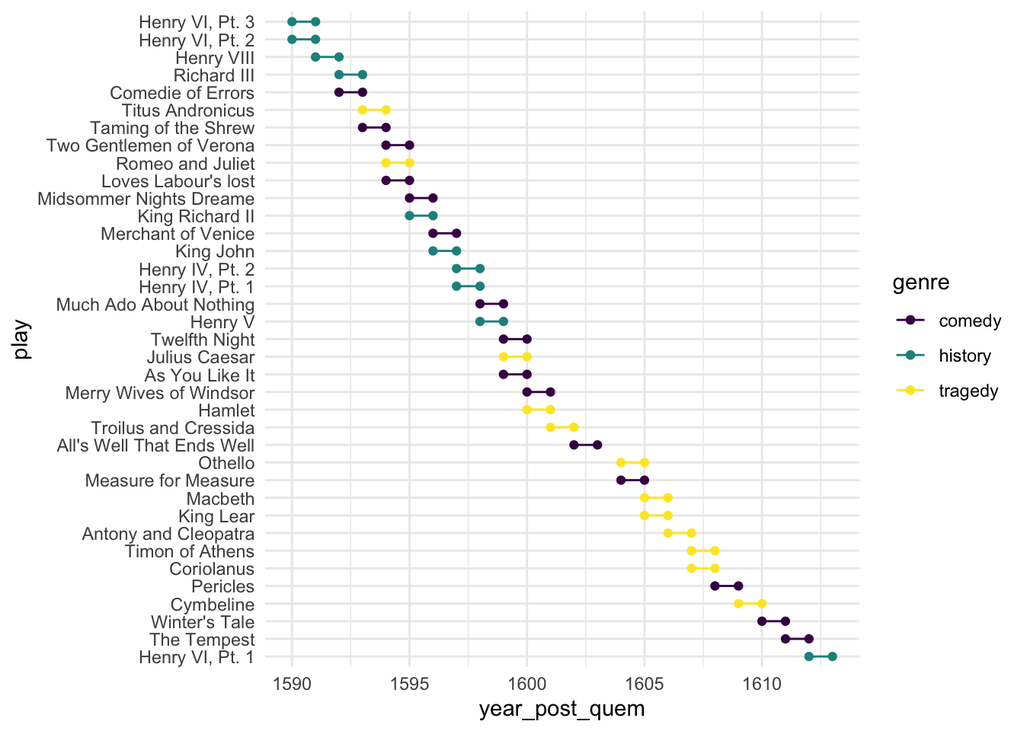

```r
# Question 01
plays |>
  arrange(desc(year_post_quem)) |>
  mutate(play = fct_inorder(play)) |>
  ggplot(aes(year_post_quem, play)) +
    geom_point(aes(color = genre)) +
    geom_point(aes(x = year_ante_quem, color = genre)) +
    geom_segment(aes(xend = year_ante_quem, yend = play, color = genre)) +
    scale_color_viridis_d()
```

### Play length

Produce a visualization that shows the length of each play in number of lines. Again, try to show the relationship between genre and play length.

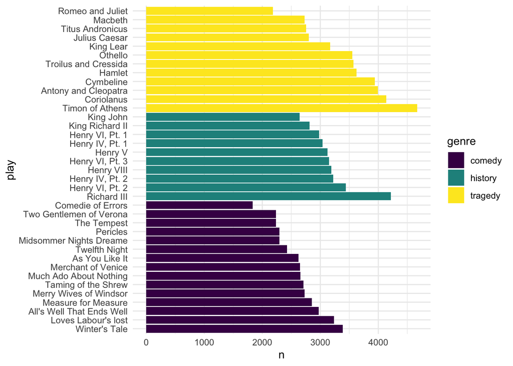

```r
# Question 02
lines |>
  group_by(play) |>
  summarize(n = n()) |>
  left_join(plays, by = "play") |>
  arrange(genre, desc(n)) |>
  mutate(play = fct_inorder(play)) |>
  ggplot(aes(n, play)) +
    geom_col(aes(fill = genre)) +
    scale_fill_viridis_d()
```

### Narrative Form

Take a single play, perhaps one that you are vaguely familiar with. Visualize when each character is speaking in the play and show how these lines relate to the Act of the play.

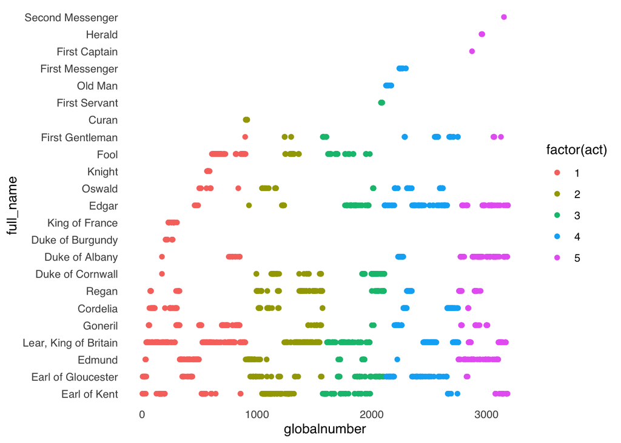

```r
# Question 03
lines |>
  filter(play == "King Lear") |>
  mutate(full_name = fct_inorder(full_name)) |>
  ggplot(aes(globalnumber, full_name)) +
    geom_point(aes(color = factor(act))) +
    theme_tufte()
```

Can you create a similar plot showing only the N characters that have the most lines in the play? (You can pick a good N with some experimentation on your own data).

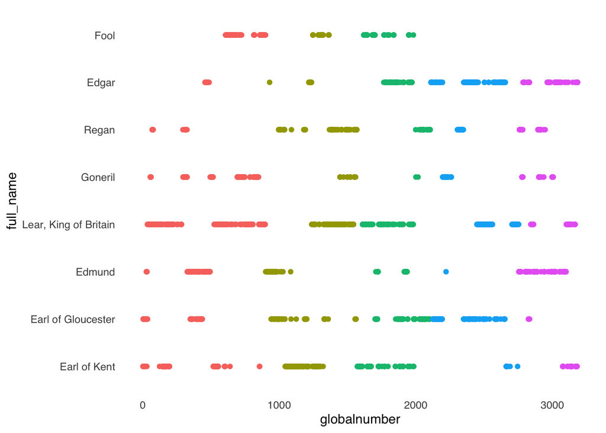

```r
# Question 04
characters_to_include <- lines |>
  filter(play == "King Lear") |>
  group_by(play, full_name) |>
  summarize(n = n()) |>
  arrange(desc(n)) |>
  slice(1:8)

lines |>
  semi_join(characters_to_include, by = c("play", "full_name")) |>
  mutate(full_name = fct_inorder(full_name)) |>
  ggplot(aes(globalnumber, full_name)) +
    geom_point(aes(color = factor(act)), show.legend = FALSE) +
    theme_tufte()
```

### Characters

Two ways that we can establish the prominence of a character is through the number of total lines they have as well as the number of long speech they have. As a starting point, assuming long speaches are over 20 lines. Produce a visualization showing the relationship between these two measurements for the most prolific characters in the dataset. This might take several steps.

Feel free to adjust the number of characters and the length of a “long speech” and see how it affects the output.

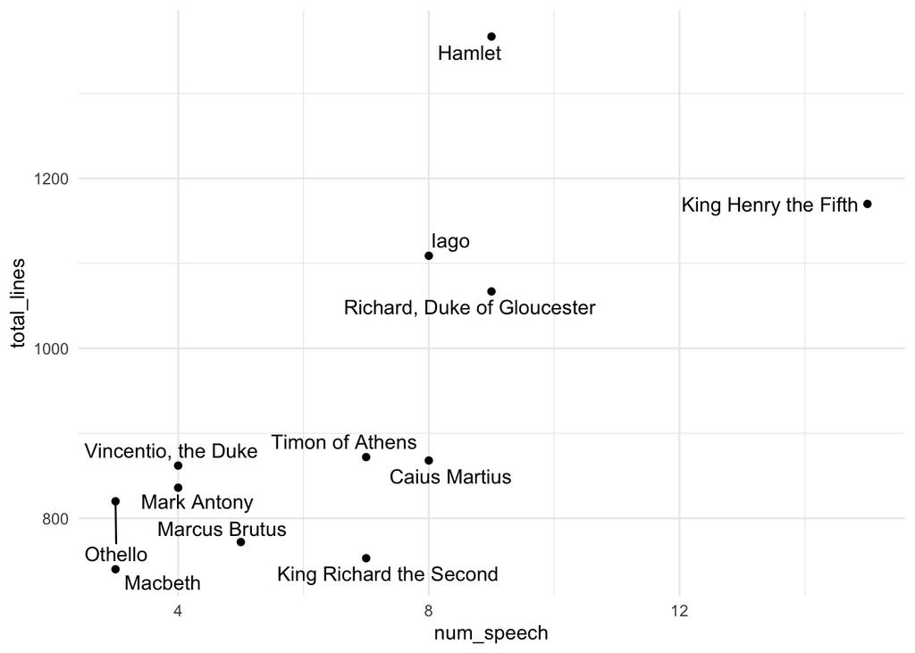

```r
# Question 05
line_total <- lines |>
  group_by(play, full_name) |>
  summarize(total_lines = n()) |>
  ungroup() |>
  arrange(desc(total_lines)) |>
  slice(1:12)

lines |>
  group_by(play, full_name, speech_id) |>
  summarize(n = n()) |>
  filter(n > 20) |>
  group_by(play, full_name) |>
  summarize(num_speech = n()) |>
  inner_join(line_total, by = c("play", "full_name")) |>
  ggplot(aes(num_speech, total_lines)) +
    geom_point() +
    geom_text_repel(aes(label = full_name))
```

### Character Gender

Visualize the proportion of lines spoken by female characters in each play.

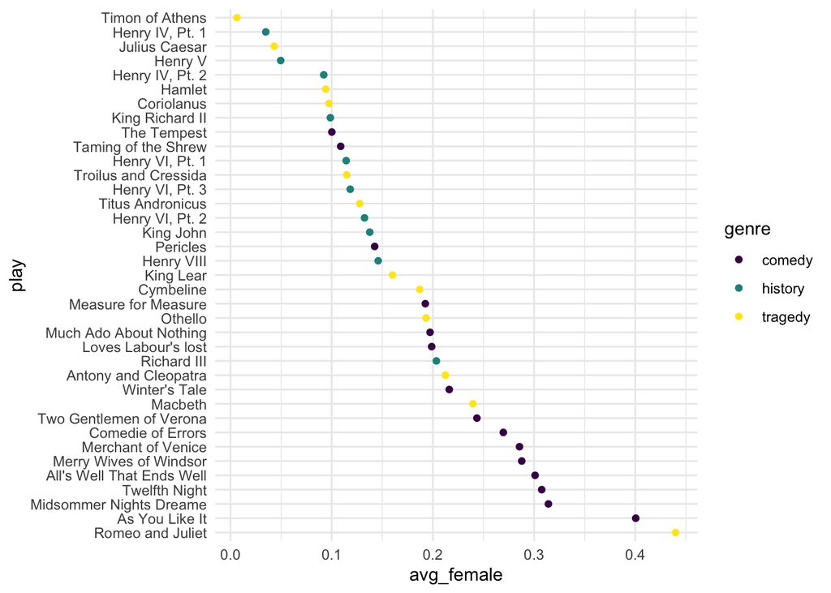

```r
# Question 06
lines |>
  left_join(people, by = c("play", "full_name")) |>
  group_by(play) |>
  summarize(avg_female = mean(gender == "female")) |>
  left_join(plays, by = "play") |>
  arrange(desc(avg_female)) |>
  mutate(play = fct_inorder(play)) |>
  ggplot(aes(avg_female, play)) +
    geom_point(aes(color = genre)) +
    scale_color_viridis_d()
```

Then, use a `geom_density` layer to show how the proportion of female character lines changes with genre.

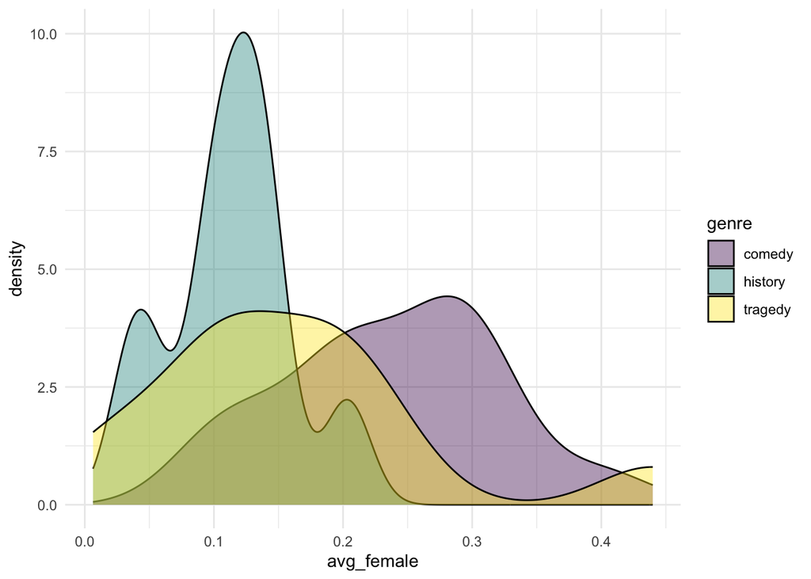

```r
# Question 07
lines |>
  left_join(people, by = c("play", "full_name")) |>
  group_by(play) |>
  summarize(avg_female = mean(gender == "female")) |>
  left_join(plays, by = "play") |>
  ggplot(aes(avg_female)) +
    geom_density(aes(fill = genre), alpha = 0.4) +
    scale_fill_viridis_d()
```

### Narrative Arc

Using a set of the characters that have the most overall lines across the data, visualize the number of lines a character has in the first two acts compared their number of lines in acts 4 and 5.

Note that some plays do not have a full five acts (Hamlet) in the folio version and you may want to remove those from the plot.

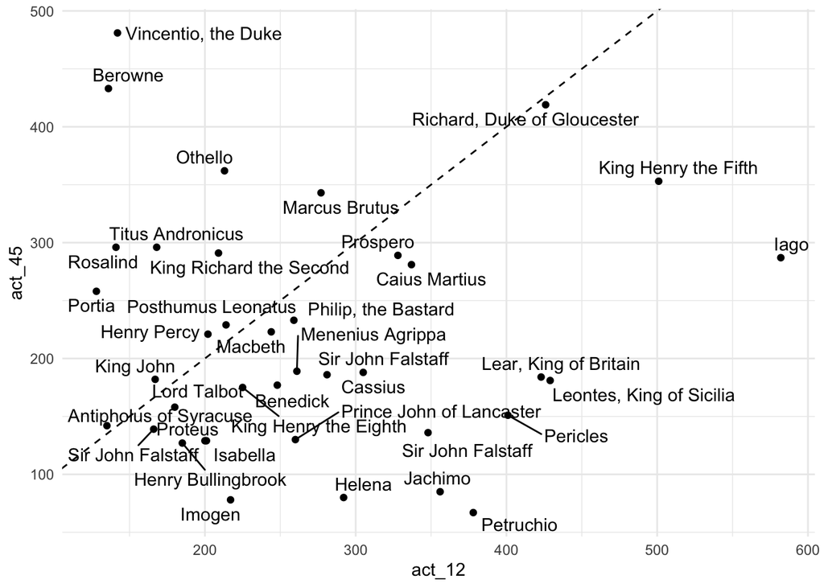

```r
# Question 08
line_total <- lines |>
  group_by(play, full_name) |>
  summarize(total_lines = n()) |>
  ungroup() |>
  arrange(desc(total_lines)) |>
  slice(1:50)

lines |>
  semi_join(line_total, by = c("play", "full_name")) |>
  group_by(act, full_name, play) |>
  summarize(n = n()) |>
  pivot_wider(names_from = "act", names_prefix = "act_", values_from = n, values_fill = 0) |>
  mutate(act_12 = act_1 + act_2, act_45 = act_4 + act_5) |>
  filter(act_45 > 0) |>
  ggplot(aes(act_12, act_45)) +
    geom_point() +
    geom_text_repel(aes(label = full_name)) +
    geom_abline(intercept = 0, slope = 1, linetype = "dashed")
```

### Extensions?

If you have time, try to extend one of the plots above with another idea or modification of the question I asked as a way of understanding the data.